# Converting to and from Document-Term Matrix and Corpus objects

Julia Silge and David Robinson

2018-05-28

### Tidying document-term matrices

Many existing text mining datasets are in the form of a `DocumentTermMatrix` class (from the tm package). For example, consider the corpus of 2246 Associated Press articles from the topicmodels package:

```r
library(tm)
data("AssociatedPress", package = "topicmodels")
AssociatedPress
```

```
## <<DocumentTermMatrix (documents: 2246, terms: 10473)>>
## Non-/sparse entries: 302031/23220327
## Sparsity           : 99%
## Maximal term length: 18
## Weighting          : term frequency (tf)
```

If we want to analyze this with tidy tools, we need to turn it into a one-term-per-document-per-row data frame first. The `tidy` function does this. (For more on the tidy verb, [see the broom package](https://github.com/dgrtwo/broom)).

```r
library(dplyr)
library(tidytext)

ap_td <- tidy(AssociatedPress)
```

Just as shown in this vignette, having the text in this format is convenient for analysis with the tidytext package. For example, you can perform sentiment analysis on these newspaper articles.

```r
ap_sentiments <- ap_td %>%
  inner_join(get_sentiments("bing"), by = c(term = "word"))

ap_sentiments
```

```
## # A tibble: 30,094 x 4
##    document term    count sentiment
##       <int> <chr>   <dbl> <chr>
##  1        1 assault    1. negative
##  2        1 complex    1. negative
##  3        1 death      1. negative
##  4        1 died       1. negative
##  5        1 good       2. positive
##  6        1 illness    1. negative
##  7        1 killed     2. negative
##  8        1 like       2. positive
##  9        1 liked      1. positive
## 10        1 miracle    1. positive
## # ... with 30,084 more rows
```

We can find the most negative documents:

```r
library(tidyr)

ap_sentiments %>%
  count(document, sentiment, wt = count) %>%
  spread(sentiment, n, fill = 0) %>%
  mutate(sentiment = positive - negative) %>%
  arrange(sentiment)
```

```
## # A tibble: 2,190 x 4
##    document negative positive sentiment
##       <int>    <dbl>    <dbl>     <dbl>
##  1     1251      54.       6.      -48.
##  2     1380      53.       5.      -48.
##  3      531      51.       9.      -42.
##  4       43      45.      11.      -34.
##  5     1263      44.      10.      -34.
##  6     2178      40.       6.      -34.
##  7      334      45.      12.      -33.
##  8     1664      38.       5.      -33.
##  9     2147      47.      14.      -33.
## 10      516      38.       6.      -32.
## # ... with 2,180 more rows
```

Or visualize which words contributed to positive and negative sentiment:

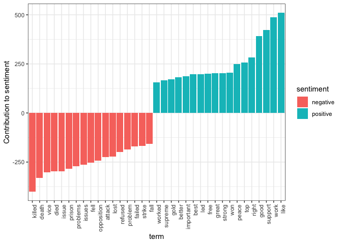

```r
library(ggplot2)

ap_sentiments %>%
  count(sentiment, term, wt = count) %>%
  filter(n >= 150) %>%
  mutate(n = ifelse(sentiment == "negative", -n, n)) %>%
  mutate(term = reorder(term, n)) %>%
  ggplot(aes(term, n, fill = sentiment)) +
  geom_bar(stat = "identity") +
  theme(axis.text.x = element_text(angle = 90, hjust = 1)) +
  ylab("Contribution to sentiment")
```

Note that a tidier is also available for the `dfm` class from the quanteda package:

```r
library(methods)

data("data_corpus_inaugural", package = "quanteda")
d <- quanteda::dfm(data_corpus_inaugural, verbose = FALSE)

d
```

```
## Document-feature matrix of: 58 documents, 9,357 features (91.8% sparse).
```

```r
tidy(d)
```

```
## # A tibble: 44,709 x 3
##    document        term            count
##    <chr>           <chr>           <dbl>
##  1 1789-Washington fellow-citizens    1.
##  2 1797-Adams      fellow-citizens    3.
##  3 1801-Jefferson  fellow-citizens    2.
##  4 1809-Madison    fellow-citizens    1.
##  5 1813-Madison    fellow-citizens    1.
##  6 1817-Monroe     fellow-citizens    5.
##  7 1821-Monroe     fellow-citizens    1.
##  8 1841-Harrison   fellow-citizens   11.
##  9 1845-Polk       fellow-citizens    1.
## 10 1849-Taylor     fellow-citizens    1.
## # ... with 44,699 more rows
```

### Casting tidy text data into a DocumentTermMatrix

Some existing text mining tools or algorithms work only on sparse document-term matrices. Therefore, tidytext provides `cast_` verbs for converting from a tidy form to these matrices.

```r
ap_td
```

```
## # A tibble: 302,031 x 3
##    document term       count
##       <int> <chr>      <dbl>
##  1        1 adding        1.
##  2        1 adult         2.
##  3        1 ago           1.
##  4        1 alcohol       1.
##  5        1 allegedly     1.
##  6        1 allen         1.
##  7        1 apparently    2.
##  8        1 appeared      1.
##  9        1 arrested      1.
## 10        1 assault       1.
## # ... with 302,021 more rows
```

```r
# cast into a Document-Term Matrix
ap_td %>%
  cast_dtm(document, term, count)
```

```
## <<DocumentTermMatrix (documents: 2246, terms: 10473)>>
## Non-/sparse entries: 302031/23220327
## Sparsity           : 99%
## Maximal term length: 18
## Weighting          : term frequency (tf)
```

```r
# cast into a Term-Document Matrix
ap_td %>%
  cast_tdm(term, document, count)
```

```
## <<TermDocumentMatrix (terms: 10473, documents: 2246)>>
## Non-/sparse entries: 302031/23220327
## Sparsity           : 99%
## Maximal term length: 18
## Weighting          : term frequency (tf)
```

```r
# cast into quanteda's dfm
ap_td %>%
  cast_dfm(term, document, count)
```

```
## Document-feature matrix of: 10,473 documents, 2,246 features (98.7% sparse).
```

```r
# cast into a Matrix object
m <- ap_td %>%
  cast_sparse(document, term, count)
class(m)
```

```
## [1] "dgCMatrix"
## attr(,"package")
## [1] "Matrix"
```

```r
dim(m)
```

```
## [1]  2246 10473
```

This allows for easy reading, filtering, and processing to be done using dplyr and other tidy tools, after which the data can be converted into a document-term matrix for machine learning applications.

### Tidying corpus data

```r
reut21578 <- system.file("texts", "crude", package = "tm")
reuters <- VCorpus(DirSource(reut21578),
                   readerControl = list(reader = readReut21578XMLasPlain))

reuters
```

```
## <<VCorpus>>
## Metadata:  corpus specific: 0, document level (indexed): 0
## Content:  documents: 20
```

The `tidy` verb creates a table with one row per document:

```r
reuters_td <- tidy(reuters)
reuters_td
```

```
## # A tibble: 20 x 17
##    author  datetimestamp       description heading   id    language origin
##    <chr>   <dttm>              <chr>       <chr>     <chr> <chr>    <chr>
##  1 <NA>    1987-02-26 10:00:56 ""          DIAMOND … 127   en       Reute…
##  2 BY TED… 1987-02-26 10:34:11 ""          OPEC MAY… 144   en       Reute…
##  3 <NA>    1987-02-26 11:18:00 ""          TEXACO C… 191   en       Reute…
##  4 <NA>    1987-02-26 11:21:01 ""          MARATHON… 194   en       Reute…
##  5 <NA>    1987-02-26 12:00:57 ""          HOUSTON … 211   en       Reute…
##  6 <NA>    1987-02-28 20:25:46 ""          KUWAIT S… 236   en       Reute…
##  7 By Jer… 1987-02-28 20:39:14 ""          INDONESI… 237   en       Reute…
##  8 <NA>    1987-02-28 22:27:27 ""          SAUDI RI… 242   en       Reute…
##  9 <NA>    1987-03-01 01:22:30 ""          QATAR UN… 246   en       Reute…
## 10 <NA>    1987-03-01 11:31:44 ""          SAUDI AR… 248   en       Reute…
## 11 <NA>    1987-03-01 18:05:49 ""          SAUDI FE… 273   en       Reute…
## 12 <NA>    1987-03-02 00:39:23 ""          GULF ARA… 349   en       Reute…
## 13 <NA>    1987-03-02 00:43:22 ""          SAUDI AR… 352   en       Reute…
## 14 <NA>    1987-03-02 00:43:41 ""          KUWAIT M… 353   en       Reute…
## 15 <NA>    1987-03-02 01:25:42 ""          PHILADEL… 368   en       Reute…
## 16 <NA>    1987-03-02 04:20:05 ""          STUDY GR… 489   en       Reute…
## 17 <NA>    1987-03-02 04:28:26 ""          STUDY GR… 502   en       Reute…
## 18 <NA>    1987-03-02 05:13:46 ""          UNOCAL <… 543   en       Reute…
## 19 By BER… 1987-03-02 07:38:34 ""          NYMEX WI… 704   en       Reute…
## 20 <NA>    1987-03-02 07:49:06 ""          ARGENTIN… 708   en       Reute…
## # ... with 10 more variables: topics <chr>, lewissplit <chr>,
## #   cgisplit <chr>, oldid <chr>, topics_cat <list>, places <list>,
## #   people <chr>, orgs <chr>, exchanges <chr>, text <chr>
```

Similarly, you can `tidy` a `corpus` object from the quanteda package:

```r
library(quanteda)

data("data_corpus_inaugural")

data_corpus_inaugural
```

```
## Corpus consisting of 58 documents and 3 docvars.
```

```r
inaug_td <- tidy(data_corpus_inaugural)
inaug_td
```

```
## # A tibble: 58 x 4
##    text                                           Year President FirstName
##  * <chr>                                         <dbl> <chr>     <chr>
##  1 "Fellow-Citizens of the Senate and of the Ho… 1789. Washingt… George
##  2 "Fellow citizens, I am again called upon by … 1793. Washingt… George
##  3 "When it was first perceived, in early times… 1797. Adams     John
##  4 "Friends and Fellow Citizens:\n\nCalled upon… 1801. Jefferson Thomas
##  5 "Proceeding, fellow citizens, to that qualif… 1805. Jefferson Thomas
##  6 "Unwilling to depart from examples of the mo… 1809. Madison   James
##  7 "About to add the solemnity of an oath to th… 1813. Madison   James
##  8 "I should be destitute of feeling if I was n… 1817. Monroe    James
##  9 "Fellow citizens, I shall not attempt to des… 1821. Monroe    James
## 10 "In compliance with an usage coeval with the… 1825. Adams     John Qui…
## # ... with 48 more rows
```

This lets us work with tidy tools like `unnest_tokens` to analyze the text alongside the metadata.

```r
inaug_words <- inaug_td %>%
  unnest_tokens(word, text) %>%
  anti_join(stop_words)

inaug_words
```

```
## # A tibble: 50,156 x 4
##     Year President  FirstName word
##    <dbl> <chr>      <chr>     <chr>
##  1 1789. Washington George    fellow
##  2 1789. Washington George    citizens
##  3 1789. Washington George    senate
##  4 1789. Washington George    house
##  5 1789. Washington George    representatives
##  6 1789. Washington George    vicissitudes
##  7 1789. Washington George    incident
##  8 1789. Washington George    life
##  9 1789. Washington George    event
## 10 1789. Washington George    filled
## # ... with 50,146 more rows
```

We could then, for example, see how the appearance of a word changes over time:

```r
inaug_freq <- inaug_words %>%
  count(Year, word) %>%
  complete(Year, word, fill = list(n = 0)) %>%
  group_by(Year) %>%
  mutate(year_total = sum(n),
         percent = n / year_total) %>%
  ungroup()

inaug_freq
```

```
## # A tibble: 501,990 x 5
##     Year word            n year_total percent
##    <dbl> <chr>       <dbl>      <dbl>   <dbl>
##  1 1789. 1              0.       529. 0.
##  2 1789. 1,000          0.       529. 0.
##  3 1789. 100            0.       529. 0.
##  4 1789. 100,000,000    0.       529. 0.
##  5 1789. 120,000,000    0.       529. 0.
##  6 1789. 125            0.       529. 0.
##  7 1789. 13             0.       529. 0.
##  8 1789. 14th           1.       529. 0.00189
##  9 1789. 15th           0.       529. 0.
## 10 1789. 16             0.       529. 0.
## # ... with 501,980 more rows
```

For example, we can use the broom package to perform logistic regression on each word.

```r
models <- inaug_freq %>%
  group_by(word) %>%
  filter(sum(n) > 50) %>%
  do(tidy(glm(cbind(n, year_total - n) ~ Year, .,
              family = "binomial"))) %>%
  ungroup() %>%
  filter(term == "Year")

models
```

```
## # A tibble: 114 x 6
##    word           term  estimate std.error statistic  p.value
##    <chr>          <chr>    <dbl>     <dbl>     <dbl>    <dbl>
##  1 act            Year   0.00636   0.00215      2.96 3.10e- 3
##  2 action         Year   0.00209   0.00190      1.10 2.71e- 1
##  3 administration Year  -0.00667   0.00184     -3.63 2.84e- 4
##  4 america        Year   0.0200    0.00154     13.0  2.02e-38
##  5 american       Year   0.00818   0.00127      6.43 1.32e-10
##  6 americans      Year   0.0316    0.00346      9.14 6.22e-20
##  7 authority      Year  -0.00585   0.00232     -2.53 1.15e- 2
##  8 business       Year   0.00332   0.00199      1.67 9.48e- 2
##  9 called         Year  -0.00222   0.00207     -1.07 2.83e- 1
## 10 century        Year   0.0155    0.00242      6.41 1.45e-10
## # ... with 104 more rows
```

```r
models %>%
  filter(term == "Year") %>%
  arrange(desc(abs(estimate)))
```

```
## # A tibble: 114 x 6
##    word      term  estimate std.error statistic  p.value
##    <chr>     <chr>    <dbl>     <dbl>     <dbl>    <dbl>
##  1 americans Year    0.0316  0.00346       9.14 6.22e-20
##  2 america   Year    0.0200  0.00154      13.0  2.02e-38
##  3 century   Year    0.0155  0.00242       6.41 1.45e-10
##  4 live      Year    0.0140  0.00242       5.79 6.92e- 9
##  5 god       Year    0.0139  0.00187       7.45 9.67e-14
##  6 democracy Year    0.0135  0.00233       5.78 7.31e- 9
##  7 earth     Year    0.0129  0.00223       5.81 6.13e- 9
##  8 freedom   Year    0.0128  0.00128       9.99 1.66e-23
##  9 powers    Year   -0.0123  0.00197      -6.24 4.32e-10
## 10 world     Year    0.0120  0.000974     12.3  7.10e-35
## # ... with 104 more rows
```

You can show these models as a volcano plot, which compares the effect size with the significance:

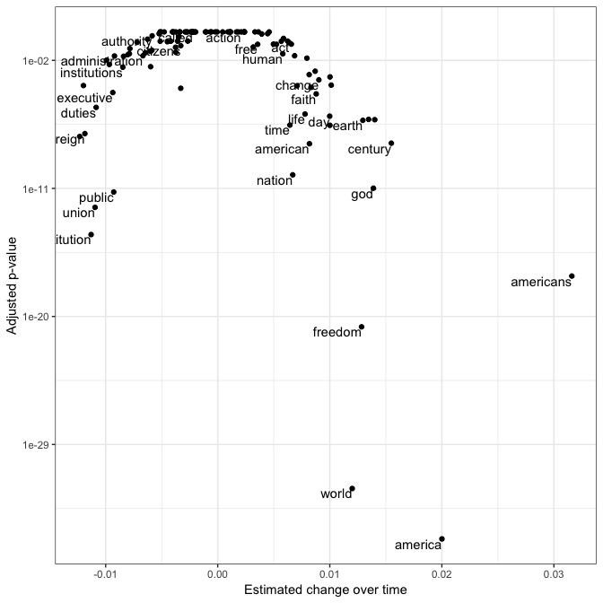

```r
library(ggplot2)

models %>%
  mutate(adjusted.p.value = p.adjust(p.value)) %>%
  ggplot(aes(estimate, adjusted.p.value)) +
  geom_point() +
  scale_y_log10() +
  geom_text(aes(label = word), vjust = 1, hjust = 1,
            check_overlap = TRUE) +
  xlab("Estimated change over time") +
  ylab("Adjusted p-value")
```

We can also use the ggplot2 package to display the top 6 terms that have changed in frequency over time.

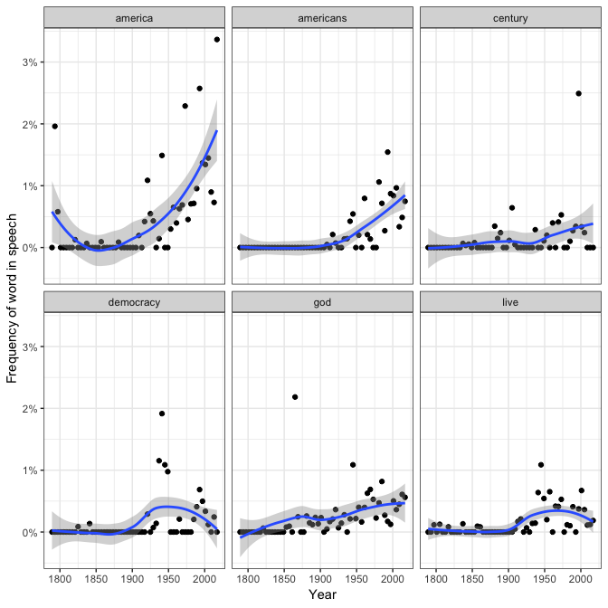

```r
library(scales)

models %>%
  top_n(6, abs(estimate)) %>%
  inner_join(inaug_freq) %>%
  ggplot(aes(Year, percent)) +
  geom_point() +
  geom_smooth() +
  facet_wrap(~ word) +
  scale_y_continuous(labels = percent_format()) +
  ylab("Frequency of word in speech")
```